# Ecological Classical Political Economy

Workshop Notes. Otto-Friedrich-Universität Bamberg, April 4-6 2022

Oriol Vallès Codina, Research Fellow, Leeds University Business School, JUST2CE Project.

April 4 - 6 2022

# Schedule

| **Monday, Apr 4** | **Tuesday, April 5** | **Wednesday, April 6** |
| --- | --- | --- |
| Basics and Varieties of Dynamical Systems | Lotka-Volterra Prey-Predator Oscillations | Early Agent-Based Models in Complexity Science: Cellular Automata and the Ising Model |
| Discrete Models: Logistic Growth, Stability and Chaos | Economic Application 1: The Goodwin Model of Capital Accumulation and Class Struggle | Economic Application of the van der Pol Oscillator: Kaldor’s Business Cycle |
| Economic Application: Ricardian Growth in a World of Limited Resources | Economic Application 2: The Flaschel-Semmler Model of Multi-Sector Growth |  |

# Complex Dynamical Systems

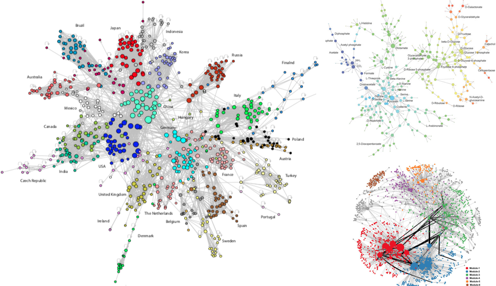

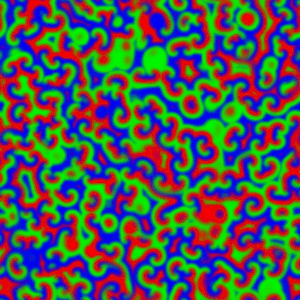

*Belousov-Zhabotinsky Chemical Reactions*

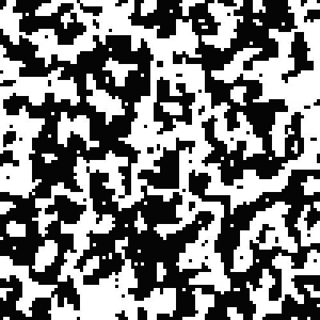

*Phase Transition in the Ising Model*

Complexity theory studies highly organized but decentralized systems composed of very large numbers of individual components, with common features that transcend its differences in scale, material components, and organizing laws. They are:

- **complex**, showing the potential to configure their component parts in an astronomically large number of ways,
- **adaptive**, undergoing constant change in response to environmental stimulus and their own development,
- **self-organizing**, exhibiting a strong tendency to achieve recognizable, stable patterns in their configuration, and
- **non-equilibrium systems**, avoiding stable, strictly self-reproducing states

Such models first emerged as applications of corporate-managerial problems in the mid-1950s out of systems thinking, a causality-driven, holistic approach that describes the interactions between the components of a system and their interaction with its environment.

For Brian Arthur (2014, 92), complex adaptive systems are characterized by six features that posit difficulties for the traditional mathematics used in economics:

- dispersed interaction among (heterogeneous) agents,
- existence of no global controller,
- cross-cutting hierarchical organization,
- continual adaptation,
- perpetual novelty, and
- out-of-equilibrium dynamics

### Five “Big Ideas” that distinguish complexity economics from traditional (neoclassical) economics (table 4.1, Beinhocker 2006, 97)

|  | Complexity Economics | Neoclassical Economics |
| --- | --- | --- |
| **Dynamics** | Open, dynamic, nonlinear systems, far from equilibrium | Closed, static, linear systems in equilibrium |
| **Agents** | Modeled individually; use inductive rules of thumb to make decisions; have incomplete information; are subject to errors and biases; learn and adapt over time | Modeled collectively; use complex deductive calculations to make decisions; have complete information; make no errors and have no biases; have no need for learning or adaptation (are already perfect) |
| **Networks** | Explicitly model interactions between individual agents; networks of relationships change over time | Assume agents only interact indirectly through market mechanisms (e.g., auctions) |
| **Emergence** | No distinction between micro- and macroeconomics; macro patterns are emergent result of micro-level behaviors and interactions | Micro- and macroeconomics remain separate disciplines |
| **Evolution** | The evolutionary process of differentiation, selection, and amplification provides the system with novelty and is responsible for its growth in order and complexity | No mechanism for endogenously creating novelty, or growth in order and complexity |

### Table 2.1, Mirowski (1996), p.15

- **Romanticism** wholist, historicist, intedeterminist, emotivist, experimental, diversity, aesthetic detachment, organicism, perspectival
- **Classicism** atomist, atemporal, determinist, stoic, formal, uniformity, interventionist control, mechanicism, aperspectival

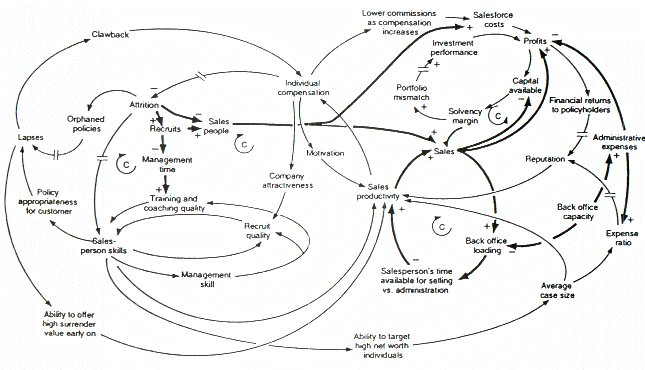

*Causal loop diagram of a model examining the growth or decline of a life insurance company*

# Basics of Dynamical Systems

## Definitions

In many sciences dynamical systems play a central role in the description of reality. The basic idea is to represent the **state of a system** at a particular time $t$ in terms of measurements, i.e. different variables or dimensions, which is called the **state vector** $x(t)$. The space in which the state vector is defined (usually a finite-dimensional Euclidean space) is called the **state space**. The basic idea of a dynamical system is that **certain laws of motion** govern the evolution of the state vector.

Hence we can define a dynamical system as a state space $S$, a set of times $T$, and a rule $R$ that regulates the temporal evolution of the system:
$$R: S \times T \to S$$

- State space $S$ can be **continuous** or **discrete** (e.g. cellular automata or Markov chains)
- Rule $R$ can be **deterministic** (including deterministic chaos) or **stochastic** (e.g. Markov chains, but also the FitzHugh-Nagumo model of a spiking neuron). Rules $R$ are often characterized by a set of ordinary differential equations that deterministically relate the current state of a system to a future state of the system.

**Discrete Maps**

Dynamical systems that operate over discrete time and a continuous state space, of the form
$$f: S \to S$$
. If $x_t$ describes the system at time $t$, a discrete map is characterized by
$$x_{t+1} = f(x_t)$$

The most famous example is the *logistic map*:
$$x_{t+1}= rx (1 - \frac{x}{K})$$

**Continuous-Time Flows**

Deterministic dynamical systems on a manifold $M$ (subset of Euclidean space)
$$\phi: R \times M \to M$$
, with an orbit $x(t) = \phi_t (x(0))$. They are generally written as a set of differential equations,
$$\dot{x} = \phi(x)$$
. Flows can generate cycles in two dimensions and chaos in three dimensions. Turbulence can also be described by a dynamical system operating on a complex manifold. ODEs are deterministic, which implies that orbits cannot intersect themselves.

**Equilibrium**

$x^*$ is the equilibrium or fixed point of a dynamical system if:
$$x^* =
f(x^*) \quad \text{in the discrete case}$$
$$f(x^*) = 0 \quad \text{in the continuous
case}$$

**Kinds of Fixed Points**

Fixed points can be:

- a **sink** if orbits lead to it
- a **source** if orbits run away from it,
- a **center** if they are center of stable cycles, or
- a **saddle** if orbits in one direction lead to it while they run away from it in the other.

**Attractor**

Roughly speaking, a subset of the state space to which orbits originating from typical initial conditions tend as time increases: e.g. “butterfly-effect” [Lorenz Attractor](https://en.wikipedia.org/wiki/Lorenz_system), [Rossler Attractor](https://en.wikipedia.org/wiki/R%C3%B6ssler_attractor).

**Basin of Attraction**

Set of initial conditions leading to long-time behavior that approaches that attractor. The qualitative behavior of the long-time motion of a given system can be fundamentally different depending on which basin of attraction the initial condition lies in (e.g. attractors can correspond to periodic, quasiperiodic or chaotic behaviors of different types).

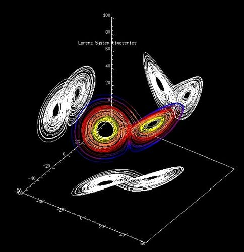

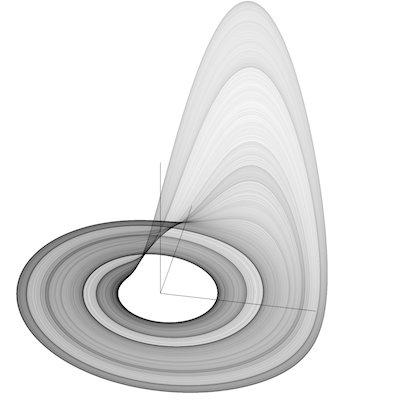

## Dynamical Behavior

### Linear Systems

In vectorial form,
$$\begin{pmatrix}
x_1(t+1) \\ \ldots \\ x_N(t+1) \\ \end{pmatrix} = A \begin{pmatrix}
x_1(t) \\ \ldots \\ x_N(t) \\ \end{pmatrix}$$
In matricial form,
$$x_{t+1} = A x_t$$
In ‘most’ cases, the matrix $A$ has an *eigenspace*, characterized by $N$ eigenvalues $\lambda_1,\ldots,\lambda_N$ with corresponding eigenvectors $w_1,\ldots,w_N$:
$$A w_i = \lambda_i w_i, \qquad i = 1,\ldots,N$$
Computing
$$\det (A - \lambda I)
=0$$
produces the *characteristic equation* with **eigenvalues** as their roots.

A general analytical solution for the linear discrete-time system is:
$$\begin{pmatrix} x_1(t+1) \\ \ldots \\
x_N(t+1) \\ \end{pmatrix} = b_1 \lambda^t_1 w_1 + \ldots + b_N
\lambda^t_N w_N$$

In continuous time, nontrivial solutions will be of the form
$$x(t) = e^{\lambda t} u$$
where $u$ is the (eigen)vector of real or complex constants and $\lambda$ is the real or complex eigenvalue.

### Stability

The fixed point is:

- a **source**, i.e. is **unstable** if the eigenvalues are real and positive (above one module in the discrete-time case),
- a **sink**, i.e. is **stable** if the eigenvalues are real and negative (below one module in the discrete-time case),
- a **saddle-point** if one eigenvalue is real positive and the other is real negative,
- a **center** producing **oscillations** if the eigenvalues are complex conjugates with zero real component. The non-negative real component will add amplification or dampening to the oscillations

In the long term, i.e. for $t \to \infty$, there are two qualitatively distinct cases: convergence to or oscillations around the fixed point.

**Convergence**

Let $\lambda$ be the eigenvalue of $A$ with the largest absolute value, i.e. the *dominant* eigenvalue, and let $w$ be the corresponding eigenvector. Then, if $\lambda$ is a real number, the long-term behaviour is given by:
$$\begin{pmatrix} x_1(t) \\ \ldots \\ x_N(t) \\ \end{pmatrix} = b
\lambda^t w \qquad \text{for } t \to \infty$$
where $bw$ is the component of the initial condition in the direction of the eigenvector $w$. If $\lambda$ is real positive (negative), the dynamic variables will eventually grow (shrink) at a rate $\lambda$, and the vector of variables will be a multiple of $w$, the dominant eigenvector indicating the balanced-growth path of the system. In economics, the balanced-growth path (Von Neumann 1945) is called equilibrium and the dominant eigenvector $w$ plays the role to the Sraffian `standard commodity’ (Sraffa 1960), while the dominant eigenvalue corresponds to the maximum rate of expansion (Shaikh 2016).

**Oscillations**

If $\lambda$ is complex, $\lambda_+ = r + is = c(\cos \phi + i \sin \phi)$ with $\phi \neq 0$, then $w = u + iv$ with $v \neq 0$, and the complex conjugate $\lambda_- r - is$ is also an eigenvalue of $A$ with corresponding eigenvector $w = u - iv$. The real-valued solution will eventually converge to oscillating behavior with exponentially increasing (or decreasing) amplitude:
$$\begin{pmatrix} x_1(t) \\ \ldots \\ x_N(t) \\ \end{pmatrix} = c^t
\left[ b_1 \left(\cos \phi t \cdot u - \sin \phi t \cdot v \right) +
b_2 \left( b_1 \cos \phi t \cdot u - \sin \phi t \cdot v \right) \right]
\quad \text{for } t \to \infty$$
where $c = \sqrt{r^2 + s^2}$ is the absolute value of $\lambda$ and $b_1$ and $b_2$ are determined from the initial condition.

## Nonlinear Systems

This procedure is very helpful to compute the stability of fixed points of nonlinear systems. In order to do so, we compute the **Jacobian matrix** of the system evaluated at its fixed points. For instance, in two dimensions we have, for a continuous-time system:
$$\begin{cases} \dot{x} = f_1(x,y) \\ \dot{y} = f_2(x,y) \end{cases}$$
The Jacobian is
$$J_{(x^*,y^*)} (f) = \begin{pmatrix} \frac{\partial f_1}{\partial x}
& \frac{\partial f_1}{\partial y} \\ \frac{\partial f_2}{\partial x}
& \frac{\partial f_2}{\partial y} \end{pmatrix}$$
Computing
$$\det (J - \lambda I) =0$$
produces the characteristic equation with eigenvalues $\lambda$ as their roots.

Here you have a [practical example](https://math.stackexchange.com/questions/1015231/jacobian-matrix-in-dynamical-systems) including a phase portrait.

### Trace-Determinant Method

We can write the determinant of the two-dimensional system as
$$\det(A - \lambda I) = \lambda^2 -
\underbrace{(a+d)}_{\text{trace}} \lambda +
\underbrace{(ad-bc)}_{\text{determinant}} = \lambda^2 + T \lambda + D$$
The eigenvalues of $A$ are given by
$$\lambda = \frac{T \pm \sqrt{T^2 -
4D}}{2}$$
- If $T^2 - 4D > 0$ we have two distinct real eigenvalues - If $T^2 - 4D < 0$ we have two complex eigenvalues that are conjugate - If $T^2 - 4D = 0$ we have repeated eigenvalues

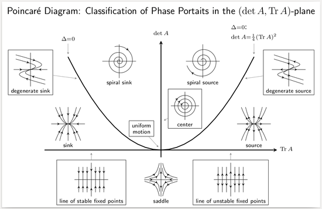

*Classification of Phase Portraits in Two Dimensions in terms of the trace and the determinant of A*

## Bifurcation Theory

**Definition**

A bifurcation occurs when a small smooth quantitative change made to the parameter values (the bifurcation parameters) of a system causes a sudden ``qualitative” or topological change in its behavior. Bifurcations occur in both continuous systems (described by ODEs, DDEs or PDEs) and discrete systems (described by maps). Saddle-node bifurcations may be associated with hysteresis loops and catastrophes Rosser (2000).

**Saddle-Node**

In a [saddle-node bifurcation](https://en.wikipedia.org/wiki/Saddle-node_bifurcation), two fixed points (or equilibria) of a dynamical system collide and annihilate each other. An example is
$$\dot{x} = r + x^2,$$
with fixed point $x^* = \sqrt{-r}$. If $r<0$, there are two equilibrium points, a stable point at $-\sqrt{-r}$ and an unstable point at $\sqrt{-r}$. At $r=0$ there is the bifurcation with one equilibrium point with saddle-node stability. If $r>0$ there are no equilibrium points.

**Pitchfork**

A [pitchfork bifurcation](https://en.wikipedia.org/wiki/Pitchfork_bifurcation) is a particular type of local bifurcation where the system transitions from one fixed point to three fixed points. Pitchfork bifurcations can be supercritical, where a stable fixed point becomes unstable while ``giving birth” to two stable fixed points. Example:
$$\dot{x} = rx - x^3; \quad x^* =
\begin{cases} 0 \\ \pm \sqrt{r} \end{cases}$$
In the subcritical case, an unstable fixed point becomes stable while giving birth to two unstable fixed points. Example:
$$\dot{x} =
rx + x^3; \quad x^* = \begin{cases} 0 \\ \pm \sqrt{-r}
\end{cases}$$

**Transcritical**

A [transcritical bifurcation](https://en.wikipedia.org/wiki/Transcritical_bifurcation) is one in which a fixed point exists for all values of a parameter and is never destroyed. However, such a fixed point interchanges its stability with another fixed point as the parameter is varied. In other words, both before and after the bifurcation, there is one unstable and one stable fixed point. However, their stability is exchanged when they collide. So the unstable fixed point becomes stable and vice versa. The normal form is
$$\dot{x}
= r x - x^2$$

**Hopf**

A [Hopf bifurcation](https://en.wikipedia.org/wiki/Hopf_bifurcation) is a critical point where a system’s stability switches and a periodic solution (i.e. oscillations) arises.

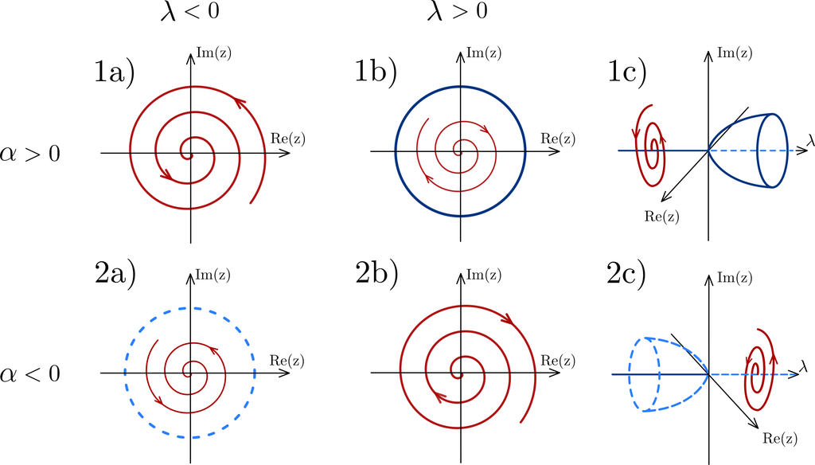

Hopf bifurcations occur in the Lotka–Volterra model of predator–prey interaction (known as paradox of enrichment), the Hodgkin–Huxley model for nerve membrane, the Selkov model of glycolysis, the Belousov–Zhabotinsky reaction, the Lorenz attractor, and the Brusselator.

**Period-Doubling**

A [period doubling bifurcation](https://en.wikipedia.org/wiki/Period-doubling_bifurcation) in a discrete dynamical system is a bifurcation in which a slight change in a parameter value in the system’s equations leads to the system switching to a new behavior with twice the period of the original system. With the doubled period, it takes twice as many iterations as before for the numerical values visited by the system to repeat themselves. A period doubling cascade is a sequence of doublings and further doublings of the repeating period, as the parameter is adjusted further and further. The most famous example is the logistic map, where period doubling leads to chaos in the form of aperiodic oscillations.

**Exponential Growth in a Limited-Resource World**

| **Model** | **Dimensions** | **Topic** |
| --- | --- | --- |
| Bhaduri-Harris | 1 | Complex Dynamics of the Simple Ricardian System |

**Predator-Prey Oscillations with 2+ Dimensions**

| **Model** | **Dimensions** | **Topic** | **Prey** | **Predator** |
| --- | --- | --- | --- | --- |
| Goodwin | 2 | Distribution | employment rate | labor share of income |
| Flaschel-Semmler | $2N$ | Growth | prices/profits | quantities/capital |

# R Setup

Check first if our version of `R` is the latest, otherwise download it from the Comprehensive R Archive Network (CRAN) in https://www.r-project.org/ >> *Download >> CRAN* >> Select your mirror.

Check for useful R Cheatsheets in https://www.rstudio.com/resources/cheatsheets/.

```r
# Download and install RStudio
# Also latest version of R from https://ftp.fau.de/cran/
version
```

```
##                _
## platform       x86_64-apple-darwin17.0
## arch           x86_64
## os             darwin17.0
## system         x86_64, darwin17.0
## status
## major          4
## minor          1.3
## year           2022
## month          03
## day            10
## svn rev        81868
## language       R
## version.string R version 4.1.3 (2022-03-10)
## nickname       One Push-Up
```

We are using `Markdown` for our notes: check https://www.markdownguide.org/ for its basic and extended syntax and https://bookdown.org/yihui/rmarkdown/, the R Markdown: The Definitive Guide by Yihui Xie.

[figure not shown]

*When writing code, remember to be nice to your future self (and others)!*

# Logistic Growth

$$x_{t+1} = r x_t (1 - x_t)$$
where $x_t$ is a number between zero and one that represents the ratio of existing population to the maximum possible population $K$. The values of interest for the parameter $r$ are those in the interval [0,4]. This nonlinear difference equation is intended to capture two effects:

- **reproduction** where the population will increase at a rate proportional to the current population when the population size is small.
- **density-dependent starvation** where the growth rate will decrease at a rate proportional to the value obtained by taking the theoretical “carrying capacity” $K$ of the environment less the current population.

## Fixed Points

The fixed points are found by computing the solutions of $f(x)=x$:
$$x =
rx - rx^2$$
$$r x^2 + (1-r)x =
x(rx+1-r) = 0$$
There are two fixed points, but only one is non-trivial:

$$x^* = \begin{cases} 0 \\ \frac{r-1}{r}
= 1 - \frac{1}{r} \end{cases}$$

## Stability Analysis

In order to derive the stability of the fixed points, we take the derivative of $f(x) = rx(1-x)$ and evaluate it at the fixed points. The derivative of $f(x)$ is
$$f'(x) = r (1-2x)$$
evaluated at $x^*$:
$$f'(0)=r$$
Hence, $x^*_1 = 0$ will be stable if $r < 1$ and unstable if $r > 1$.
$$f'(\frac{r-1}{r}) = 2-r$$
The second fixed point $x^*_2 = 1 - 1/r$ will be unstable if $r<1$, stable if $1<r<3$, and unstable again if $r>3$.

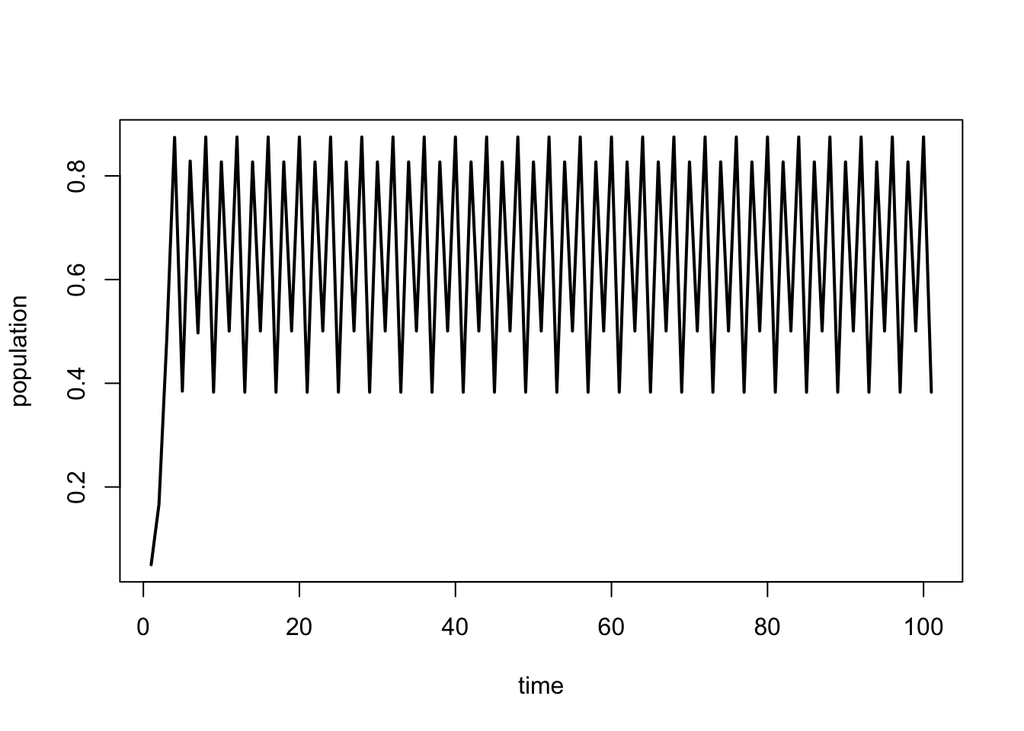

```r
# LOGISTIC MAP
x <- c()
x[1] <- 0.05 # initial condition
r <- 3.5 # parameter

for (t in 1 : 100) x[t+1] <- r * x[t] * (1 - x[t])

plot(x, type='l', lwd=2, xlab = 'time', ylab = 'population')
```

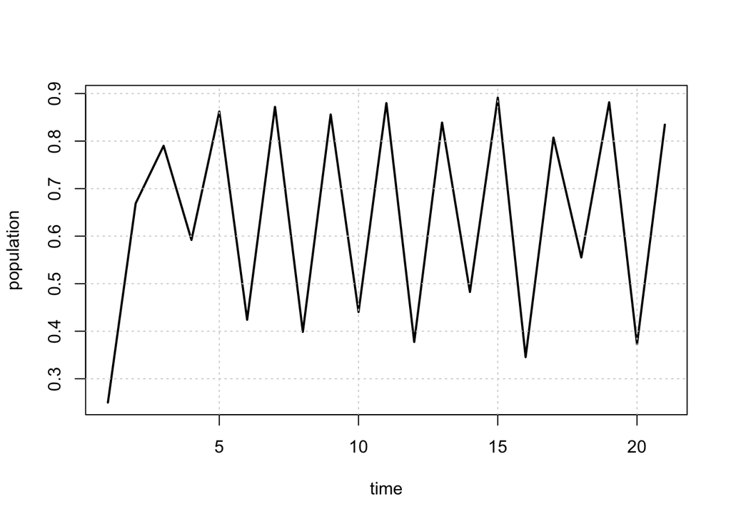

```r
# We can write a function logistic
# Three local variables: initial condition; reproduction rate (r), and number of iterations
logistic <- function (init, par, time.length)
{
  x <- c()
  x[1] <- init
  for (t in 1 : time.length) x[t+1] <- par * x[t] * (1 - x[t])
  return(x)
}

plot(logistic(init = 0.25,
              par = 3.56995,
              time.length = 20),
     type='l', lwd=2, xlab='time', ylab = 'population')
grid()
```

## Dynamical Behavior

By varying the parameter $r$, the following behavior is observed.

### Starvation

> With $r$ between 0 and 1, the population will eventually die, independent of the initial population.

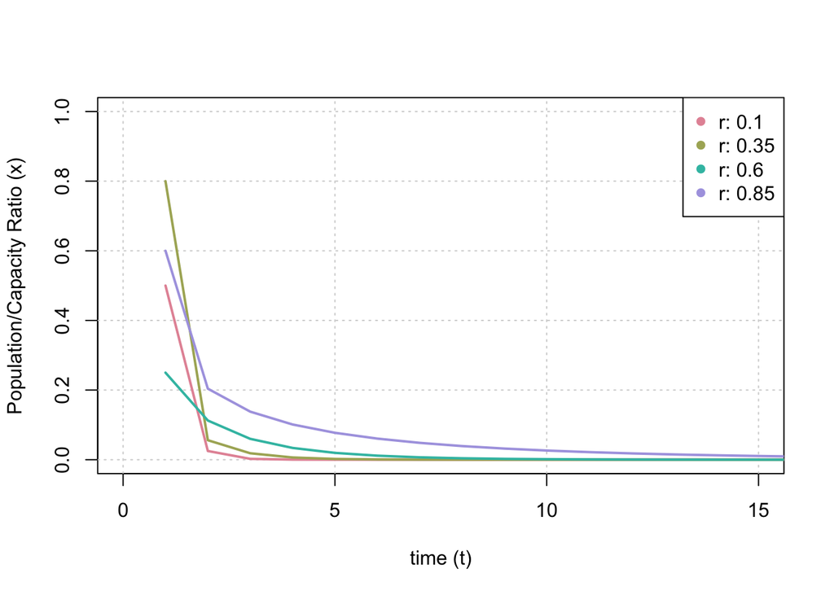

```r
library(colorspace)

tf <- 15
plot(NA, xlim=c(0,tf), ylim=c(0,1), xlab = 'time (t)', ylab = 'Population/Capacity Ratio (x)')
grid()

rval <- seq(0.1, 1, by = 0.25)
t_0 <- c(0.5, .8, .25, .6)

for(k in 1:length(rval))
{
  lines(1:(tf+1), logistic(t_0[k], rval[k], tf), col = rainbow_hcl(n = length(rval))[k], lwd=2)
}

legend('topright', paste('r:', rval), pch = 16, col = rainbow_hcl(n = length(rval)))
```

### Logistic Growth

> With $r$ between 1 and 2, the population will quickly approach the value $\frac{r-1}{r}$, independent of the initial population.

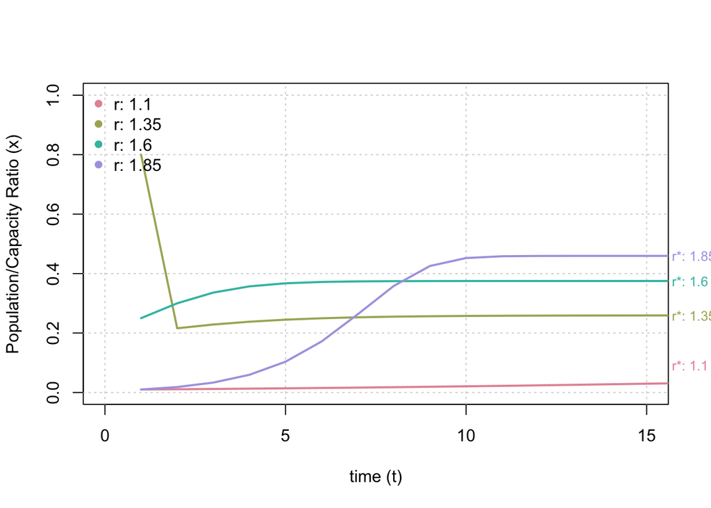

```r
plot(NA, xlim = c(0, tf), ylim = c(0,1), xlab='time (t)', ylab='Population/Capacity Ratio (x)')
grid()

rval <- seq(1.1, 2, by = 0.25)
t_0 <- c(0.01, .8, .25, .01)

for(k in 1 : length(rval))
{
  lines(1:(tf+1), logistic(t_0[k], rval[k], tf), col = rainbow_hcl(n = length(rval))[k], lwd=2)
}

mtext(paste(' r*:',rval), side = 4, at = (rval - 1)/rval, col = rainbow_hcl(n = length(rval)), las=1, cex=0.8)
legend('topleft', paste('r:', rval), pch=16, col = rainbow_hcl(n = length(rval)), bty='n')
```

### Convergence to Stability with Dampening Oscillations

> With $r$ between 2 and 3, the population will also eventually approach the same value $\frac{r-1}{r}$, but first will fluctuate around that value for some time.

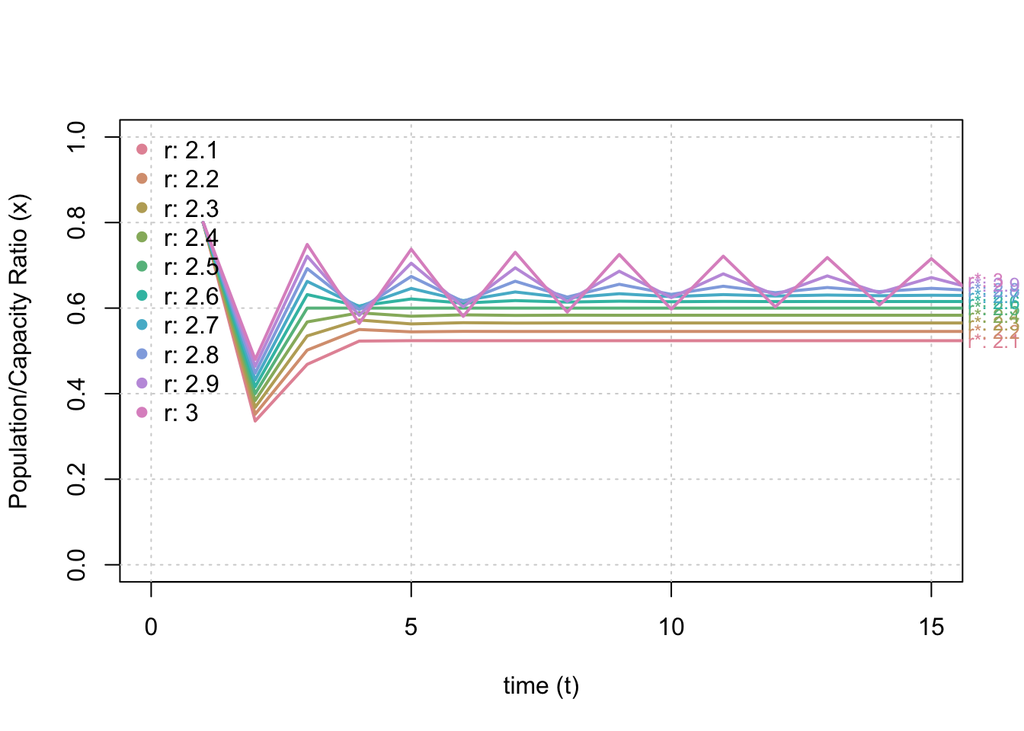

```r
plot(NA, xlim = c(0, tf), ylim = c(0,1), xlab='time (t)', ylab='Population/Capacity Ratio (x)')
grid()

rval<-seq(2.1,3,by=0.1)

for(k in 1 : length(rval))
{
  lines(1:(tf+1), logistic(0.8, rval[k], tf), col = rainbow_hcl(n = length(rval))[k], lwd=2)
}

mtext(paste(' r*:',rval), side = 4, at = (rval - 1)/rval, col = rainbow_hcl(n = length(rval)), las=1, cex=0.8)
legend('topleft', paste('r:', rval), pch=16, col = rainbow_hcl(n = length(rval)), bty='n')
```

### Periodic Oscillations

> With $r$ between 3 and $1 + \sqrt{6} \sim 3.44949$, from almost all initial conditions the population will approach permanent oscillations between two values. These two values are dependent on $r$.

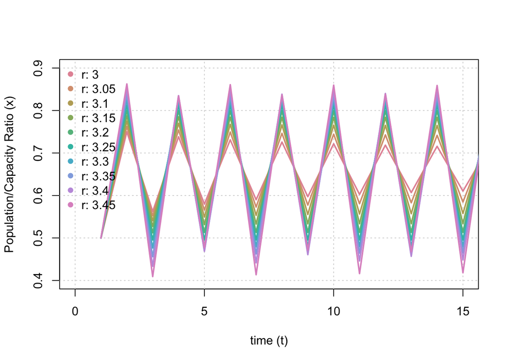

```r
plot(NA, xlim = c(0, tf), ylim = c(.4 , .9), xlab='time (t)', ylab='Population/Capacity Ratio (x)')
grid()

rval <- seq(3, 3.45, by = 0.05)
for(k in 1:length(rval))
{
  lines(1:(tf+1), logistic(0.5, rval[k], tf), col = rainbow_hcl(n = length(rval))[k], lwd=2)
}
legend('topleft',paste('r:',rval), pch = 16, col = rainbow_hcl(n = length(rval)), bty = 'n')
```

> With $r$ between 3.44949 and 3.54409 (approximately), from almost all initial conditions the population will approach permanent oscillations among four values.

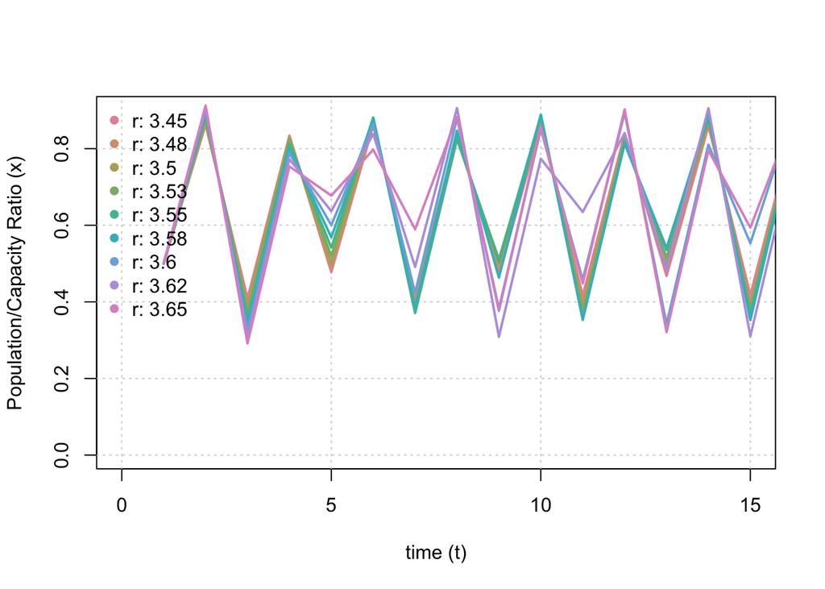

```r
plot(NA, xlim = c(0, tf), ylim = c(0, .9), xlab='time (t)', ylab='Population/Capacity Ratio (x)')

grid()
rval<-seq(3.45, 3.65, by = 0.025)

for(k in 1:length(rval))
{
  lines(1:(tf+1), logistic(0.5,rval[k],tf), col = rainbow_hcl(n = length(rval))[k], lwd=2)
}
legend('topleft', paste('r:',round(rval,2)),pch = 16,col = rainbow_hcl(n = length(rval)),bty = 'n')
```

### Onset of Chaos: the Period-Doubling Cascade

> With $r$ increasing beyond 3.54409, from almost all initial conditions the population will approach oscillations among 8 values, then 16, 32, etc. This behavior is an example of a period-doubling cascade.

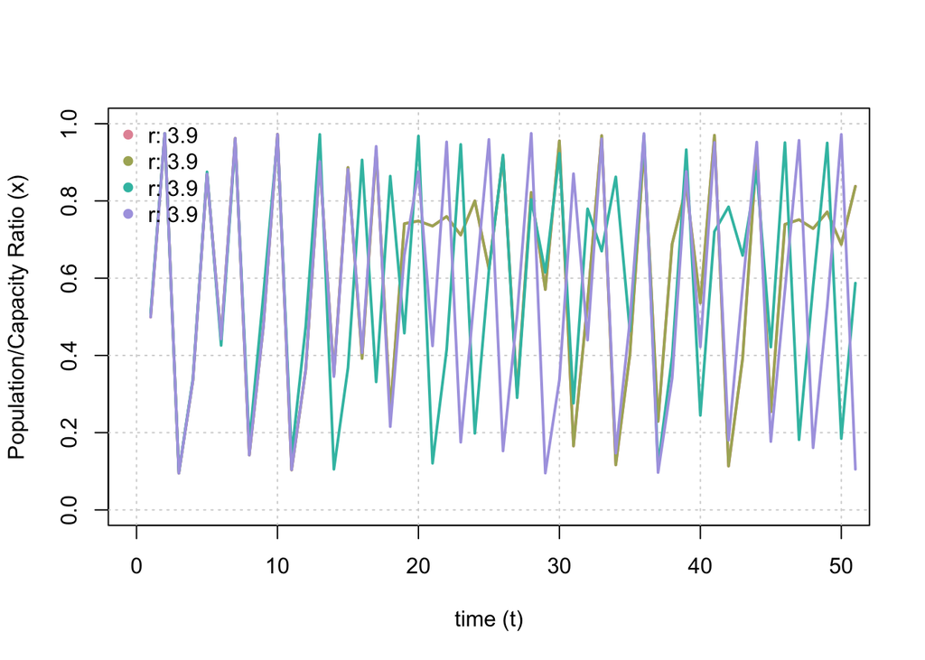

```r
tf <- 50
plot(NA, xlim = c(0,tf), ylim=c(0,1), xlab = 'time (t)',ylab = 'Population/Capacity Ratio (x)')
grid()

# rval <- seq(3.65 , 3.8, by = 0.025)
rval <- rep(3.9, 4)

lines(1:(tf+1), logistic(0.499, rval[1], tf), col = rainbow_hcl(n=length(rval))[1], lwd = 2)
lines(1:(tf+1), logistic(0.501, rval[2], tf), col = rainbow_hcl(n=length(rval))[2], lwd = 2)
lines(1:(tf+1), logistic(0.51, rval[3], tf), col = rainbow_hcl(n=length(rval))[3], lwd = 2)
lines(1:(tf+1), logistic(0.4995, rval[4], tf), col = rainbow_hcl(n=length(rval))[4], lwd = 2)

legend('topleft', paste('r:',round(rval,2)), pch=16, col = rainbow_hcl(n=length(rval)), bty='n')
```

> At $r \sim 3.56995$ is the onset of chaos, at the end of the period-doubling cascade. From almost all initial conditions, we no longer see oscillations of finite period.

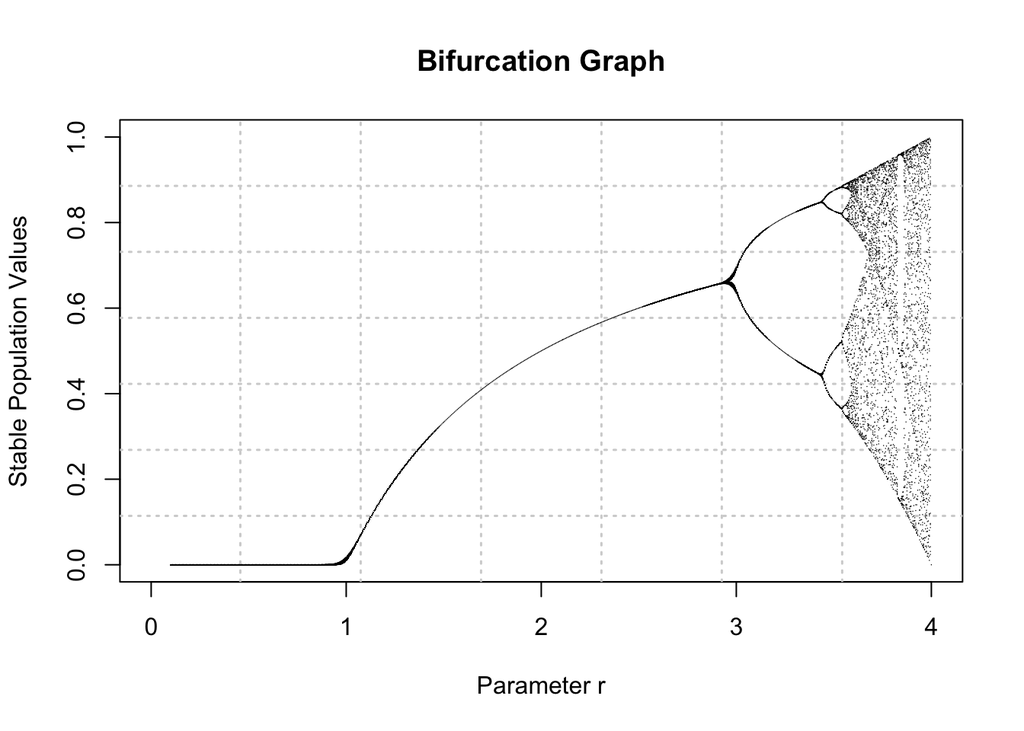

```r
plot(NA, xlim = c(0,4), ylim = c(0,1), xlab = 'Parameter r', ylab = 'Stable Population Values', main = 'Bifurcation Graph')
grid(lwd = 1.5, nx=7)

for(r in seq(0.1,4,by=.005))
{
  yy <- as.numeric(names(table(logistic(0.5, r, 100)[50:100])))
  points(rep(r, times = length(yy)), yy, pch = 16, cex = .1)
}
```

### Iteration Maps

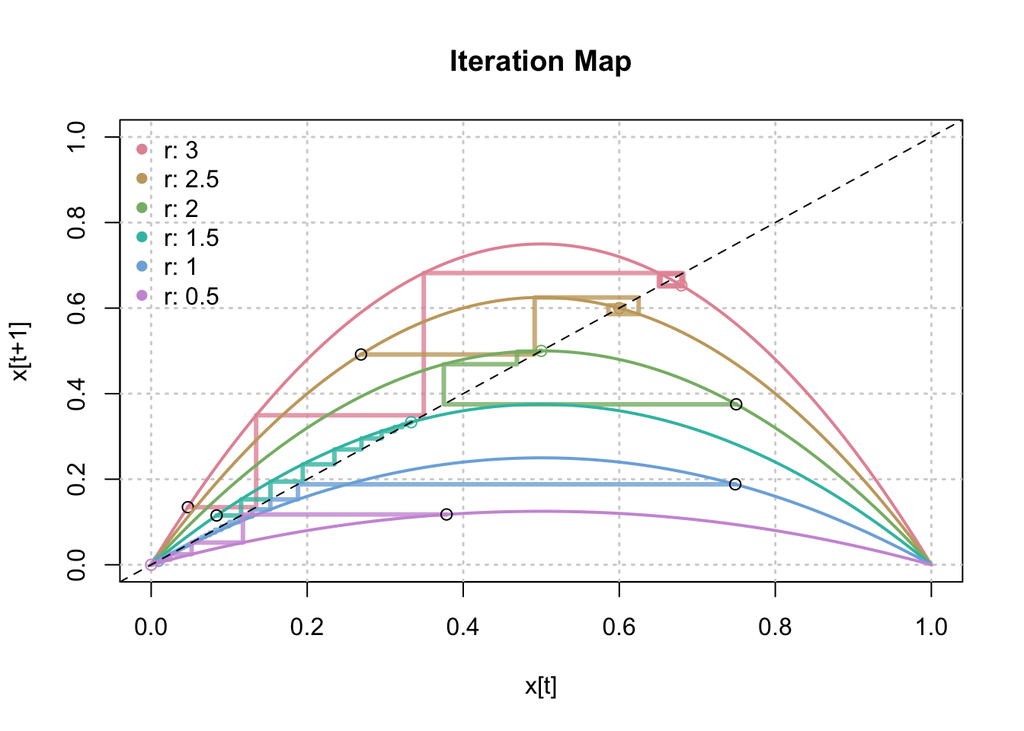

```r
plot(NA, xlim = c(0, 1), ylim = c(0, 1), xlab = 'x[t]', ylab = 'x[t+1]', main = 'Iteration Map')
grid(lwd = 1.5)

library(scales)
# lines(rep(tmp,each=2)[-c(1,202)],rep(tmp,each=2)[-c(1,2)],col=rainbow_hcl(r0[k]))
r0 <- seq(3, .5, by = -.5)

for(k in 1 : length(r0))
{
  tmp <- logistic(runif(1), r0[k], 100)

  lines(rep(tmp, each = 2)[-c(1,202)], rep(tmp,each=2)[-c(1,2)], col = alpha(rainbow_hcl(length(r0))[k],0.8), lwd = 3)

  lines(seq(0,1,by=.01),r0[k]*seq(0,1,by=.01)*(1-seq(0,1,by=.01)),col=rainbow_hcl(length(r0))[k],lwd=2)

  points(tmp[1], tmp[2])
  points(tmp[100], tmp[101], col = rainbow_hcl(length(r0))[k])
}
abline(a=0,b=1,lty=2)
legend('topleft',paste('r:',round(r0,2)),pch=16,col=rainbow_hcl(n=length(r0)),bty='n')
```

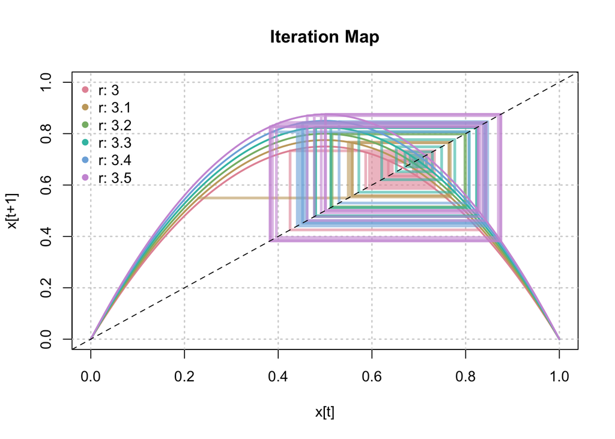

```r
plot(NA, xlim = c(0, 1), ylim = c(0, 1), xlab = 'x[t]', ylab = 'x[t+1]', main = 'Iteration Map')
grid(lwd = 1.5)

# lines(rep(tmp,each=2)[-c(1,202)],rep(tmp,each=2)[-c(1,2)],col=rainbow_hcl(r0[k]))
r0 <- seq(3, 3.5, by = .1)
for(k in 1:length(r0))
{
  tmp <- logistic( runif(1), r0[k], 100)

  lines(rep(tmp, each = 2)[-c(1,202)], rep(tmp, each=2)[-c(1,2)], col = alpha(rainbow_hcl(length(r0))[k],0.6), lwd=3)

  lines(seq(0,1,by=.01), r0[k]*seq(0,1,by=.01)*(1-seq(0,1,by=.01)), col = rainbow_hcl(length(r0))[k], lwd=2)
}
abline(a=0,b=1,lty=2)
legend('topleft',paste('r:',round(r0,2)),pch=16,col=rainbow_hcl(n=length(r0)),bty='n')
```

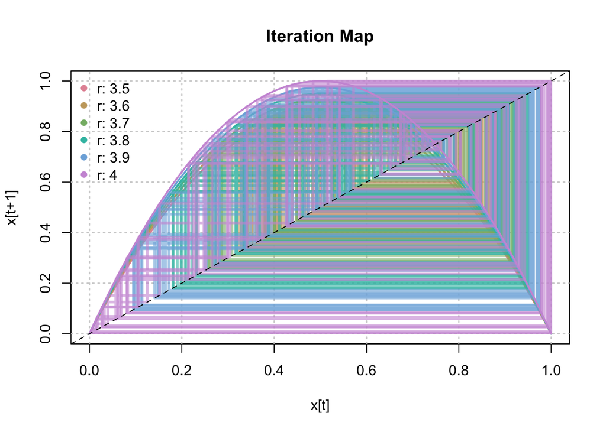

```r
plot(NA,xlim=c(0,1),ylim=c(0,1),xlab='x[t]',ylab='x[t+1]',main='Iteration Map')
grid(lwd=1.5)
# lines(rep(tmp,each=2)[-c(1,202)],rep(tmp,each=2)[-c(1,2)],col=rainbow_hcl(r0[k]))
r0<-seq(3.5,4,by=.1)
for(k in 1:length(r0))
{
  tmp<-logistic(runif(1),r0[k],100)
  lines(rep(tmp,each=2)[-c(1,202)],rep(tmp,each=2)[-c(1,2)],col=alpha(rainbow_hcl(length(r0))[k],0.6),lwd=3)
  lines(seq(0,1,by=.01),r0[k]*seq(0,1,by=.01)*(1-seq(0,1,by=.01)),col=rainbow_hcl(length(r0))[k],lwd=2)
}
abline(a=0,b=1,lty=2)
legend('topleft',paste('r:',round(r0,2)),pch=16,col=rainbow_hcl(n=length(r0)),bty='n')
```

# The Complex Dynamics of the Simple Ricardian System

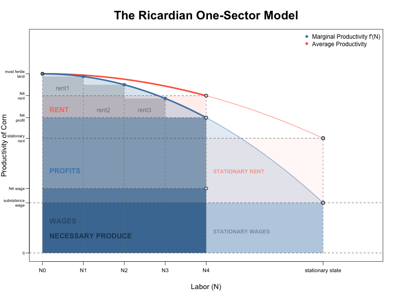

*Visual depiction of the Ricardian one-sector model following Pasinetti*

> The idea that the process of capitalist accumulation ultimately terminates in a stationary state is deeply rooted in the classical tradition of political economy. Ricardo, in particular, visualized the process of accumulation that is almost inexorably driven toward its end because the capitalists gradually lose command over the investible surplus as their profit dwindles due to increasing pressure of rent on **limited natural resources like land**. Bhaduri and Harris (1987)

Consider an economy where labor $N$ is applied in fixed proportion to less and less fertile land as the margin of cultivation is extended in the process of capital accumulation. Accordingly, there exists a falling marginal product curve for labor with fixed ``doses” of land. This curve is assumed to be linear of the form:
$$MP_t
= \frac{dY_t}{dN_t} = a - bN_t \quad a>0, \quad b>0$$
By integration, the total product curve is:
$$Y_t = aN_t - bN^2/2$$
The average product is:
$$AP_t = \frac{Y_t}{N_t} = a - bN_t/2$$
Given the margin of cultivation reach at time $t$, the level of land rent $R_t$ emerges as the difference between the average and the marginal product of labor,
$$R_t = \left( \frac{Y_t}{N_t} - \frac{dY}{dN_t} \right) N_t = bN^2_t/2$$
Profit $P_t$ is the residual after payment of rent and replacement of the wage fund $W_t$ advanced to hire labor. Thus
$$P_t = Y_t - R_t - W_t$$
It is the dynamics of the wage fund that represents the process of accumulation in this simple economy. At a given wage rate $w$ we have
$$W_t = wN_t$$
**Classical condition imposes the dynamical behavior** Accumulation of the wage fund comes entirely from reinvestment of profits accruing to capitalists:
$$W_{t+1}-W_t = P_t$$
which yields
$$N_{t+1}-N_t = \frac{P_t}{w} = \frac{a}{w} N_t -
\frac{b}{w} N^2_t - N_t$$
Finally we obtain the discrete dynamic equation:
$$N_{t+1}= \frac{a}{w} N_t - \frac{b}{w} N^2_t$$
There exists an equilibrium at
$$N_{t+1} = N_t = N^* = \frac{a-w}{b}$$
In such an equilibrium, the marginal product of labor $MP^*$ is equal to the given real wage rate $w$ so that all profit disappears $P^*=0$ and the whole surplus over the wage bill accrues to the landlords as rent – the **Ricardian stationary state**.

Since the positivity of the marginal product requires $a > bN_t$, corresponding to all economically meaningful employment levels $N_t$, we can define a new variable $n_t$ such that
$$n_t \equiv \frac{bN_t}{a}$$
which lies between 0 and 1. Consequently, the dynamic equation can be rewritten as:
$$n_{t+1} = A n_t (1-n_t)$$
where $A = a/w$. This is the equation for the logistic map. It has two fixed points, $n^*=0$ and $n^* = \frac{a-w}{a}$.

### Economic Interpretation

The degree of complexity of the dynamic behavior of the simple Ricardian system depends critically on the value of the ratio $A$. If the system is to be capable of generating any surplus over wages, then the production coefficient $a$ must exceed the wage rate $w$ and thus $A>1$ for the economy to be viable.

Rewriting $a/w$ as
$$\frac{a-w+w}{w}=1+ \frac{a-w}{w}= 1 + \epsilon_0$$
where $\epsilon_0 \equiv (a-w)/w$.

> $\epsilon_0$ corresponds to the *rate of exploitation measured in corn at the very initial state of the system*, i.e. at ``primitive accumulation”. It is also the *maximum rate of exploitation* that the system supports.

> The dynamic behavior of the system is governed in a remarkably simple way by the **distributional relations**.

The value of the crucial ratio $A$ can be expressed in terms of the distribution of income between rent and wages in the Ricardian stationary states (when profit is zero):
$$\frac{R^*}{W^*} = \frac{1}{2}
\left(\frac{a-w}{w}\right) = \frac{1}{2} (A-1)$$

**Predator-Prey Oscillations with 2+ Dimensions**

| **Model** | **Dimensions** | **Topic** | **Prey** | **Predator** |
| --- | --- | --- | --- | --- |
| Goodwin | 2 | Distribution | employment rate | labor share of income |
| Flaschel-Semmler | $2N$ | Growth | prices/profits | quantities/capital |

# Lotka-Volterra / Predator-Prey Oscillations

[figure not shown]

*The Lotka-Volterra equations are frequently used to describe the dynamics of biological systems in which two species interact.*

The Lotka-Volterra equations, also known as the predator-prey equations, are a pair of first-order nonlinear differential equations, frequently used to describe the dynamics of biological systems in which two species interact, one as a predator and the other as prey. Originally proposed in the theory of autocatalytic chemical reactions.

## Brusselator

The Brusselator is a theoretical model for a type of autocatalytic reaction. The Brusselator model was proposed by Ilya Prigogine and collaborators at the Université Libre de Bruxelles.

It is characterized by the reactions:
$$A
\to X$$
$$2 X + Y \to 3 X$$
$$B + X \to Y + D$$
$$X \to E$$
Under conditions where $A$ and $B$ are in vast excess and can thus be modeled at constant concentration, the rate equations become
$$\frac{d}{dt} \{X\} = \{A\} + \{X\}^2 \{Y\} -
\{B\}\{X\} - \{X\}$$
$$\frac{d}{dt}
\{Y\} = \{B\} \{X\} - \{X\}^2 \{Y\}$$
$$\dot{x} = a + x^2 y - (1+b)$$
$$\dot{y} = bx - x^2 y$$
where, for convenience, the rate constants have been set to 1.

The Brusselator has a fixed point at
$$\{
X \} = A; \qquad x^* = a$$
$$\{ Y \}
= \frac{B}{A} \qquad y^* = \frac{b}{a}$$

The fixed point becomes unstable when
$$B
> 1 + A^2$$
leading to an oscillation of the system. Unlike the Lotka–Volterra equation, the oscillations of the Brusselator do not depend on the amount of reactant present initially. Instead, after sufficient time, the oscillations approach a limit cycle.

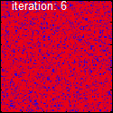

Spatial Brusselator chemicall reactions

## Model

The populations change through time according to the pair of equations:
$$\begin{cases} \dot{x} = \alpha
x - \beta xy \\ \dot{y} = \delta x y - \gamma y \end{cases}$$
$$\frac{\dot{x}}{x} = \alpha - \beta y$$
$$\frac{\dot{y}}{y} = \delta x -
\gamma$$

where $x$ and $y$ are the prey and predator populations, respectively; $\dot{x}$ and $\dot{y}$ are their growth rates; and $\alpha$, $\beta$, $\delta$, and $\gamma$ are parameters describing the interactions between the species.

### Assumptions

- The prey population finds ample food at all times.
- The food supply of the predator population depends entirely on the size of the prey population.
- The rate of change of population is proportional to its size.
- During the process, the environment does not change in favour of one species, and genetic adaptation is inconsequential.
- Predators have limitless appetite.

## Dynamical Behavior

> The Lotka-Volterra model has two fixed points: an extinction equilibrium and a characteristic limit cycle (with a shape that depends on its four parameters and oscillation amplitude that depends on the initial values for $x$ and $y$).

Population equilibrium occurs in the model when neither of the population levels is changing, i.e. when both of the derivatives are equal to 0:
$$x(\alpha - \beta y) =
0$$
$$-y (\gamma - \delta x)
=0$$
The fixed points $(x^*,y^*)$ are thus
$$x^*_1 = (0,0) \quad \text{extinction}$$
and
$$x^*_2=(\frac{\gamma}{\delta},\frac{\alpha}{\beta})
\quad \text{oscillations}$$

The stability of the fixed points can be determined by performing a linearization using partial derivatives. The Jacobian matrix of the predator–prey model is
$$J(x,y) =
\begin{pmatrix} \alpha - \beta y & - \beta x \\ \delta y &
\delta x - \gamma \end{pmatrix}$$

> In the model $\alpha$ and $\gamma$ are always greater than zero, and as such the sign of the eigenvalues above will always differ. Hence the fixed point at the origin is a **saddle point**.

The stability of this fixed point is of significance. If it were stable, non-zero populations might be attracted towards it, and as such the dynamics of the system might lead towards the extinction of both species for many cases of initial population levels. However, as the fixed point at the origin is a saddle point, and hence unstable, it follows that the extinction of both species is difficult in the model. (In fact, this could only occur if the prey were artificially completely eradicated, causing the predators to die of starvation. If the predators were eradicated, the prey population would grow without bound in this simple model.) The populations of prey and predator can get infinitesimally close to zero and still recover.

For the second fixed point (oscillations), the Jacobian yields
$$J(\frac{\gamma}{\delta},\frac{\alpha}{\beta}) =
\begin{pmatrix} 0 & -\frac{\beta \gamma}{\delta} \\ \frac{\alpha
\delta}{\beta} & 0 \end{pmatrix}$$
with conjugate pure imaginary eigenvalues
$$\lambda = \pm i
\sqrt{\alpha \gamma}$$
. As the eigenvalues are both purely imaginary and conjugate to each others, this fixed point is elliptic, so the solutions are periodic, oscillating on a small ellipse around the fixed point, with frequency
$$\omega =
\sqrt{\lambda_1 \lambda_2} = \sqrt{\alpha \gamma}$$
. As illustrated in the circulating oscillations in the figure above, the level curves are closed orbits surrounding the fixed point: the levels of the predator and prey populations cycle and oscillate without damping around the fixed point.

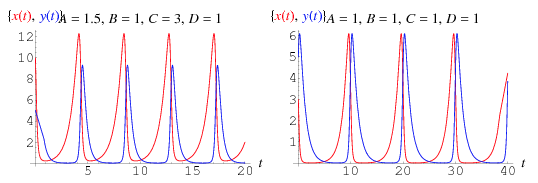

*Lotka-Volterra oscillations for two sets of parameters*

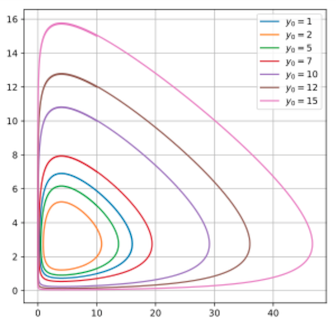

*Phase-space plot for the predator prey problem for various initial conditions of the predator population*

## Computation

The Lotka-Volterra model is in continuous time. First, we attempt to compute the problem as if it was in discrete time. In order to do so, we write the equations as:
$$x_{t+1} = x_t +
\Delta t f_x(x,y)$$
$$y_{t+1} = y_t +
\Delta t f_y(x,y)$$

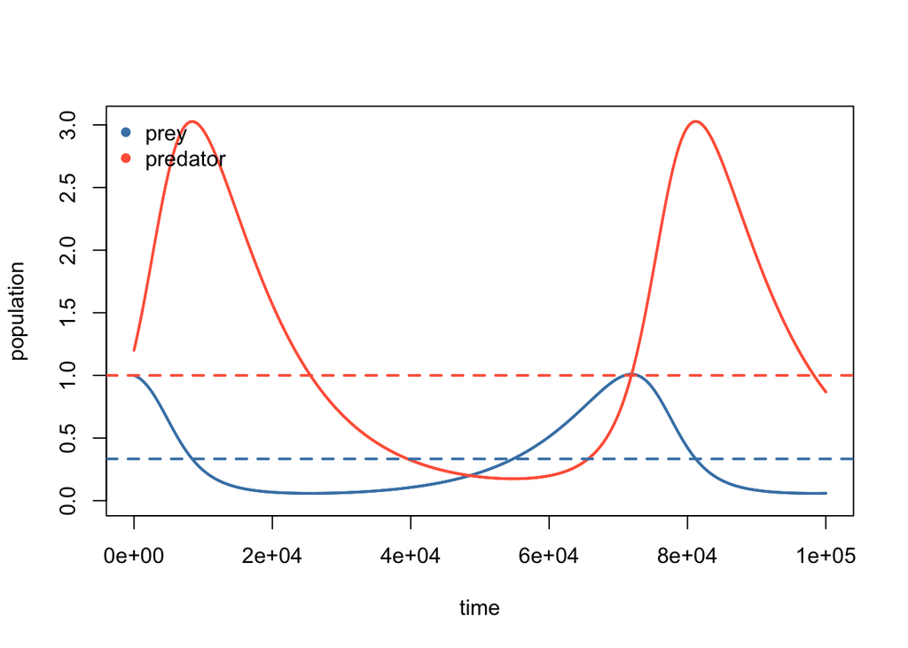

```r
alpha <- 1
beta <- 1
gamma <- 1
delta <- 1

x <- y <- c() # initialization

x[1] <- 1 # initial conditions
y[1] <- 1.2

orbit <- data.frame(x = rep(x, 10), y = rep(y, 10))

foo <- list(x, y, orbit)


interval <- .01
timelength <- 50

for(t in 1 : (timelength/interval))
{
  x[t+1] <- x[t] + interval * (alpha * x[t] - beta * x[t] * y[t])
  y[t+1] <- y[t] + interval * (delta * x[t] * y[t] - gamma * y[t])
}


lotka.volterra <- function (pars, time.length, interval, init)
{
  x <- y <- c() # initialization
  x[1] <- init[1]
  y[1] <- init[2]

  for(t in 1 : (time.length/interval))
  {
  x[t+1] <- x[t] + interval * (pars[1] * x[t] - pars[2] * x[t] * y[t])
  y[t+1] <- y[t] + interval * (pars[3] * x[t] * y[t] - pars[4] * y[t])
  }

  orbit <- data.frame(x = x, y = y)

  return(orbit)
}

parameters <- c(1,1,3,1)

orbit <- lotka.volterra(pars = parameters, time.length = 10, interval = 0.0001, init = c(1, 1.2))
timelength <- nrow(orbit)
interval <- 0.01

plot(orbit$x, type='l' , xlim = c(0, timelength), ylim=c(0, max(orbit)), xlab='time', ylab='population', col='steelblue', lwd=2)
lines(orbit$y, col='tomato', lwd=2)

alpha <- parameters[1]
beta <- parameters[2]
gamma <- parameters[3]
delta <- parameters[4]

abline(h = delta/gamma, lty=2, col = 'steelblue', lwd = 2) # fixed point for prey
abline(h = alpha/beta, lty=2, col = 'tomato', lwd = 2) # fixed point for predator

legend('topleft',c('prey','predator'), col = c('steelblue','tomato'), pch=16, bty='n')
```

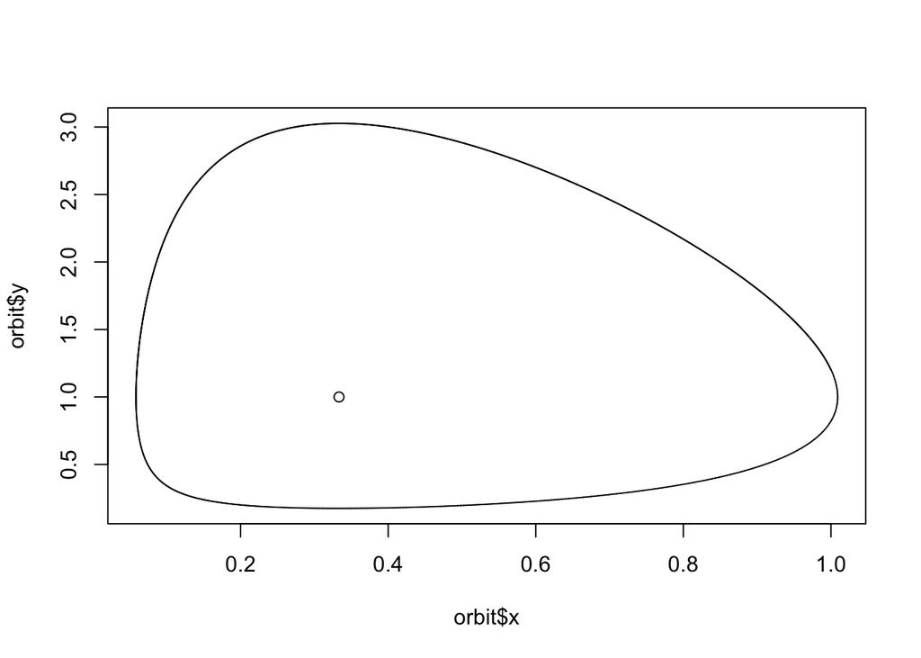

```r
# Phase Space
plot(orbit$x, orbit$y, type='l')
points(delta/gamma,alpha/beta)
```

Let’s try with another set of parameters and initial conditions:

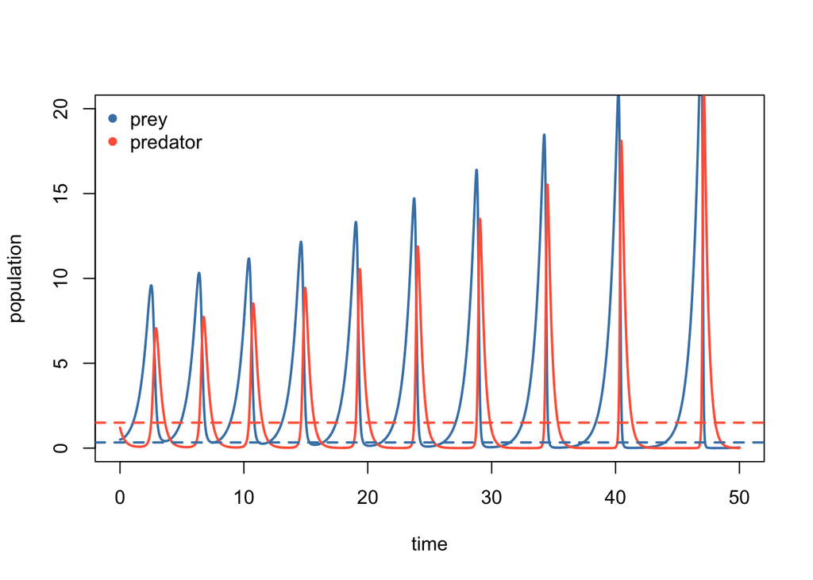

```r
alpha<-1.5
beta<-1
gamma<-3
delta<-1
x<-y<-c()
x[1]<-0.5 # initial conditions
y[1]<-1.2
interval<-.01
timelength<-50
for(t in 1:(timelength/interval))
{
  x[t+1] <- x[t]+interval*(alpha*x[t] - beta*x[t]*y[t])
  y[t+1] <- y[t]+interval*(delta*x[t]*y[t] - gamma*y[t])
}
plot(seq(0,timelength,by=interval),x,type='l',xlim=c(0,timelength),ylim=c(0,20),xlab='time',ylab='population',col='steelblue',lwd=2)
lines(seq(0,timelength,by=interval),y,col='tomato',lwd=2)
abline(h=delta/gamma,lty=2,col='steelblue',lwd=2) # fixed point x
abline(h=alpha/beta,lty=2,col='tomato',lwd=2) # fixed point y
legend('topleft',c('prey','predator'),col=c('steelblue','tomato'),pch=16,bty='n')
```